# M.TECH DATA SCIENCE AND MACHINE LEARNING (DSML)

## UE20CS936 - INTRODUCTION TO BIG DATA

## SECTION-B (40 marks)

### 1. Write HDFS shell commands for the following.

1. To print version of installed Hadoop.
2. Write command syntax for copying localfile from ‘local_src’ path of the local file system to the Hadoop filesystem path ‘hdfs_path’.
3. Write command to list the contents of folder named SampleDir.
4. Write command for display the content of the ‘sample’ file present inside newDataFlair directory of HDFS.

```python
1. hadoop version

2. hdfs dfs -copyFromLocal local_src hdfs_path
   or hdfs dfs -put local_src hdfs_path

3. hdfs dfs -ls SampleDir

4. hdfs dfs -cat /newDataFlair/sample
  🔹 This command prints the contents of the sample file stored inside the newDataFlair directory in HDFS.
```

### 2. Write HDFC shell commands for the following.

1. To print version of installed Hadoop.
2. To Copy file1.txt from folder InputDir to OutputDir as file2.txt.
3. To Delete an empty directory named as XYZ.
4. To list the contents of folder named SampleDir.
5. To fetch the usage instructions/details of mkdir command.

Note: Consider InpurDir, OutputDir, XYZ, SampleDir and file.txt are under the present working directory.

```python
1. hadoop version

2. hdfs dfs -cp InputDir/file1.txt OutputDir/file2.txt

3. hdfs dfs -rmdir XYZ
(Note: -rmdir only works if XYZ is empty. To delete a non-empty directory, use -rm -r XYZ.)

4. hdfs dfs -ls SampleDir

5. hdfs dfs -help mkdir
   or hdfs dfs -usage mkdir

hdfs dfs -help mkdir and hdfs dfs -usage mkdir are not exactly the same, but they serve similar purposes.
hdfs dfs -help mkdir: Provides detailed help with explanations.
hdfs dfs -usage mkdir: Shows a brief syntax summary of the command.
```

### 3. Write HDFS shell commands for the following.

1. How do you create a new directory in HDFS with its parent directories (if they don’t exist)
2. How do you upload multiple files from the local system to a directory in HDFS?
3. How do you display the contents of a file in HDFS line by line (paged view)?
4. How do you list all files and directories in HDFS with detailed information?
5. How do you delete a directory and its contents in HDFS?

```python
1. hdfs dfs -mkdir -p /path/to/new/directory

2. hdfs dfs -put /local/path/file1.txt /local/path/file2.txt /hdfs/destination/
   🔹 This command copies file1.txt and file2.txt from the local system to /hdfs/destination/.
   🔹 To copy all files in a local folder, use:
        hdfs dfs -put /local/path/* /hdfs/destination/

3. hdfs dfs -cat /hdfs/path/to/file.txt | less
   🔹 The less command allows scrolling through the file line by line.
   🔹 Alternatively, use:
       hdfs dfs -tail -f /hdfs/path/to/file.txt
   🔹 -tail -f continuously displays new lines added to the file in real-time.

4. hdfs dfs -ls -R /
🔹 -ls -R / lists all files and directories recursively with details like permissions, size, owner, and modification date.

5. hdfs dfs -rm -r /path/to/directory
🔹 -r removes the directory along with all its files and subdirectories.
```

### 4. Write HDFC shell commands for the following.

1. To print version of installed Hadoop.
2. To list the files and directories present in a HDFS path
3. To copy local file named file1 of the present working directory (pwd) of local file system to the Hadoop file system under root.
4. To copy the ‘testfile’ of the Hadoop filesystem (present under root) to the local file system (pwd).
5. Write command to display the content of the ‘sample’ file present inside ‘newDataFlair’ directory of HDFS.

```python
1. hadoop version

2. hdfs dfs -ls /path/to/directory
   🔹 If you want to list files and directories under the root directory, use:
        hdfs dfs -ls /

3. hdfs dfs -put file1 /
   🔹 This copies file1 from the local systems current directory to the HDFS root (/).

4. hdfs dfs -get /testfile
   🔹 This copies testfile from HDFS root (/) to the local file systems present working directory.

5. hdfs dfs -cat /newDataFlair/sample
   🔹 This command prints the contents of the sample file stored inside the newDataFlair directory in HDFS.
```

### 5. Write HDFS shell command for the following:

Suppose you have the following files in the HDFS directory /user/hadoop/input:

```
    part-0000, part-0001,  part-0002
```

You want to merge these files into a single file called merged_output.txt on your local system.

```python
Step1: List the contents of the /user/hadoop/input directory:
                     hadoop dfs -ls /user/hadoop/input

Step 2: Merge Files and Save Locally:
        hdfs dfs -getmerge /user/hadoop/input/ merged_output.txt

To add a newline between files, include the -nl option
        hadoop dfs -getmerge -nl /user/hadoop/input merged_output.txt

Step 3: Check the Local File:
Verify that merged_output.txt has been created on your local filesystem:
              cat merged_output.txt
```

### 6. Write Spark RDD commands for the following.

1. To load the given list into a spark RDD, list1 = [10, 20, 30, 40, 50].
2. Display all elements of the list.
3. Display sum of all elements of the list.
4. Display maximum value of the list.
5. Display minimum value of the list.
6. Display mean value of the elements of list.
7. Display standard deviation of elements,
8. Display variance of elements.

```python
from pyspark.sql import SparkSession

# Initialize Spark Session
spark = SparkSession.builder.appName("RDD_Operations").getOrCreate()
sc = spark.sparkContext  # Get Spark Context

# Given list
list1 = [10, 20, 30, 40, 50]

# Create an RDD from the list
rdd = sc.parallelize(list1)

2. rdd.collect()

3. rdd.sum()

4. rdd.max()

5. rdd.min()

6. rdd.mean()

7. rdd.stdev()

8. rdd.variance()
```

### 7. Write Spark RDD commands for the following.

1. Create an RDD from the list: List (1, 2, 3, 4, 5, 6)
2. Display/print first four elements of the RDD.
3. Display/print first element of the RDD.
4. Display/print the number of elements in the RDD.
5. Display sum of all elements of the RDD.
6. Display maximum value of the RDD.
7. Display minimum value of the RDD.
8. Display variance of elements of RDD.

```python
from pyspark.sql import SparkSession

# Initialize Spark Session
spark = SparkSession.builder.appName("RDD_Operations").getOrCreate()
sc = spark.sparkContext  # Get Spark Context

# Given list
list1 = [1, 2, 3, 4, 5, 6]

# Create an RDD from the list
rdd = sc.parallelize(list1)

2. rdd.take(4)

3. rdd.first()

4. rdd.count()

5. rdd.sum()

6. rdd.max()

7. rdd.min()

8. rdd.variance()
```

### 8. Write a Spark program pseudo-code to load a text file named as text.txt into Spark RDD and compute its wordcounts.

```python
# 1. Initialize a Spark Session
Initialize SparkSession with App Name "WordCountApp"

# 2. Load the text file into an RDD
Load "text.txt" into an RDD using sparkContext.textFile()

# 3. Split lines into words
Use flatMap() to split each line into words

# 4. Map each word to a (word, 1) key-value pair
Use map() to transform words into (word, 1)

# 5. Reduce by key to count occurrences
Use reduceByKey() to sum the values for each word

# 6. Collect and display the results
Use collect() to fetch the final word counts and print

# 7. Stop the Spark Session
Stop SparkSession
```

```python
from pyspark.sql import SparkSession

# 1. Initialize Spark Session
spark = SparkSession.builder.appName("WordCountApp").getOrCreate()
sc = spark.sparkContext

# 2. Load the text file into an RDD
rdd = sc.textFile("text.txt")

# 3. Split lines into words
words_rdd = rdd.flatMap(lambda line: line.split(" "))

# 4. Map each word to a (word, 1) key-value pair
word_pairs = words_rdd.map(lambda word: (word, 1))

# 5. Reduce by key to count occurrences
word_counts = word_pairs.reduceByKey(lambda a, b: a + b)

# 6. Collect and display the results
for word, count in word_counts.collect():
    print(f"{word}: {count}")

# 7. Stop the Spark Session
spark.stop()
```

### Explanation

1. Load Data: textFile("text.txt") loads the text file into an RDD.
2. Tokenization: flatMap() splits lines into words.
3. Mapping: map() converts words into key-value pairs (word, 1).
4. Counting: reduceByKey() sums up occurrences of each word.
5. Result Output: collect() gathers and prints the word counts.
6. Spark Shutdown: spark.stop() stops the session.

### 9. Write below queries in Hive;

1. Write hive query to create databases name: anotherDB.
2. Write hive query to CREATE EXTERNAL TABLE in anotherDB name it- orders1 with order_id, order_date, order_customer_id and order_status as columns
3. Write hive query to load data in orders1 table using file which is available in local file system.

```python
1. CREATE DATABASE anotherDB;

2. USE anotherDB;

CREATE EXTERNAL TABLE orders1 (
    order_id INT,
    order_date STRING,
    order_customer_id INT,
    order_status STRING
)
ROW FORMAT DELIMITED
FIELDS TERMINATED BY ','
STORED AS TEXTFILE
LOCATION '/path/to/external/directory';

3. LOAD DATA LOCAL INPATH '/path/to/local/file' INTO TABLE orders1;
```

### 10. Write below queries in Hive;

1. Write hive query to create databases name: emp.
2. Write hive query to CREATE EXTERNAL TABLE in emp name it - employee with emp_id, name, location, dep, designation and salary as columns
3. Write hive query to print average salary of employees based on location.

```python
1. CREATE DATABASE emp;

2. USE emp;

CREATE EXTERNAL TABLE employee (
    emp_id INT,
    name STRING,
    location STRING,
    dep STRING,
    designation STRING,
    salary DOUBLE
)
ROW FORMAT DELIMITED
FIELDS TERMINATED BY ','
STORED AS TEXTFILE
LOCATION '/path/to/external/directory';

3. SELECT location, AVG(salary) AS avg_salary FROM employee GROUP BY location;
```

### 11. Two hive tables are shown below. Write a hive query to perform an inner join on the Table1 and Table 2 on ‘Id’ column. Also, write the expected output of your inner join query

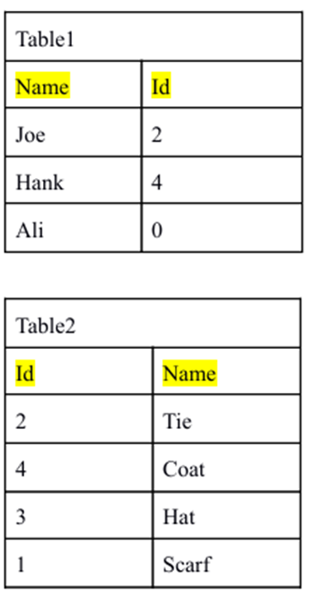

```python
SELECT
    t1.Name AS Table1_Name,
    t1.Id,
    t2.Name AS Table2_Name
FROM
    Table1 t1
INNER JOIN
    Table2 t2
ON
    t1.Id = t2.Id;
```

### Expected Output:

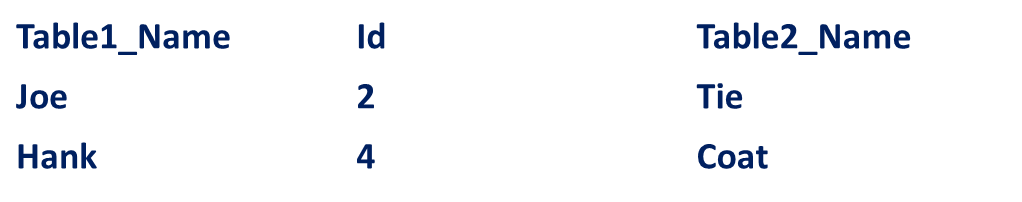

### 12. Write commands/query in MongoDB to,

1. Create a collection named orders.
2. Insert below record in orders.

   {"order_id”: 1, "order_date”: '2013-07-25 00:00:00.0', "order_customer_id”: 11599, "order_status”: "CLOSED"}
3. Fetch orders with order_status as COMPLETE.
4. Compute count of orders with status COMPLETE and CLOSED.

```python
1. db.createCollection("orders");

2. db.orders.insertOne({
    order_id: 1,
    order_date: '2013-07-25 00:00:00.0',
    order_customer_id: 11599,
    order_status: "CLOSED"
});

3. db.orders.find({ order_status: "COMPLETE" });
   This command retrieves all documents where the order_status is "COMPLETE".

4. db.orders.countDocuments({
    order_status: { $in: ["COMPLETE", "CLOSED"] }
});
```

### 13. Write commands / query in Mongo DB

1. Create a collection named users.
2. Insert below records in users.

   {name: Abhishek}, {name: Raja, age: 24}, {name: Ravi, age: 34}, {name: Ram, age: 45}, {name: Roopa, age: 44}, {name: Tina, age: 54}
3. Fetch users with age greater than or equal to 34.
4. Update record {name: Abhishek} with age 34.
5. Delete the record {name: Ravi }.

```python
1. db.createCollection("users");

2. db.users.insertMany([
    { name: "Abhishek" },
    { name: "Raja", age: 24 },
    { name: "Ravi", age: 34 },
    { name: "Ram", age: 45 },
    { name: "Roopa", age: 44 },
    { name: "Tina", age: 54 }
]);

3. db.users.find({ age: { $gte: 34 } });

4. db.users.updateOne(
    { name: "Abhishek" },
    { $set: { age: 34 } }
);

5. db.users.deleteOne({ name: "Ravi" });
```

## SECTION-C (40 marks)

### 1. Bangalore Housing Dataset is provided and loaded as Spark-DataFrame. Using Spark libraries execute the steps, as questioned below.

#### Using PySpark and Spark-SQL libraries process the dataset to find out solutions of queries mentioned below.

i. Count the total number of housing-properties listed from 'HSR Layout' location.

ii. How many ‘2 BHK’ size housing-properties are listed from 'Whitefield' location?

iii. What is the average price of ‘2 BHK’ size housing-properties in ‘HSR Layout’ location?

#### Using Spark ML execute the steps, as questioned below.

i. Remove the features, having more than one third of their entries as missing/null. For the remaining missing values- remove the corresponding row entry from the DataFrame.

ii. Convert all string columns into numeric values using StringIndexer transformer and make sure now DataFrame does not have any string columns anymore.

iii. Using vectorAssembler combines all columns (except target column i.e., 'price') of spark DataFrame into single column (name as features). Make sure DataFrame now contains only two columns features and price.

iv. Split the vectorized dataframe into training and test sets with one fourth records being held for testing

v. Train default LinearRegression model with features as 'featuresCol' and ‘price’ as label and measure RMSE value on test set

vi. Train default Factorization machines regressor model with features as 'featuresCol' and ‘price’ as label and measure RMSE value on test set. Which among LinearRegression and Factorization machines regressor model performs better?

```python
from pyspark.sql import SparkSession
from pyspark.sql.functions import col, avg, count, when
from pyspark.ml.feature import StringIndexer, VectorAssembler
from pyspark.ml.regression import LinearRegression, FMRegressor
from pyspark.ml.evaluation import RegressionEvaluator

# Initialize Spark session
spark = SparkSession.builder.appName("BangaloreHousingAnalysis").getOrCreate()

# Load the dataset
file_path = "path/to/bangalore_housing.csv"
df = spark.read.csv(file_path, header=True, inferSchema=True)

# SQL Queries using Spark-SQL
df.createOrReplaceTempView("housing")

# ---------------------- PART 1: Data Processing Using Spark SQL ----------------------

# i. Count total properties listed in 'HSR Layout'
query1 = """
    SELECT COUNT(*) AS total_properties
    FROM housing
    WHERE location = 'HSR Layout'
"""
spark.sql(query1).show()

# ii. Count of '2 BHK' properties in 'Whitefield'
query2 = """
    SELECT COUNT(*) AS total_2bhk_properties
    FROM housing
    WHERE location = 'Whitefield' AND size = '2 BHK'
"""
spark.sql(query2).show()

# iii. Average price of '2 BHK' properties in 'HSR Layout'
query3 = """
    SELECT AVG(price) AS avg_price
    FROM housing
    WHERE location = 'HSR Layout' AND size = '2 BHK'
"""
spark.sql(query3).show()

# ---------------------- PART 2: Machine Learning Using Spark ML ----------------------

# i. Remove features having more than 1/3 missing values & drop remaining null rows
threshold = df.count() / 3
df = df.dropna(thresh=threshold).dropna()

# ii. Convert string columns to numeric using StringIndexer
string_cols = [field.name for field in df.schema.fields if field.dataType == "StringType"]
indexers = [StringIndexer(inputCol=col, outputCol=col + "_indexed").fit(df) for col in string_cols]
for indexer in indexers:
    df = indexer.transform(df)
df = df.drop(*string_cols)  # Drop original string columns

# iii. Assemble all feature columns except 'price' into a single vector column
feature_cols = [col for col in df.columns if col != "price"]
assembler = VectorAssembler(inputCols=feature_cols, outputCol="features")
df = assembler.transform(df).select("features", "price")

# iv. Split data into training (75%) and test (25%)
train_df, test_df = df.randomSplit([0.75, 0.25], seed=42)

# v. Train and evaluate Linear Regression model
lr = LinearRegression(featuresCol="features", labelCol="price")
lr_model = lr.fit(train_df)
predictions_lr = lr_model.transform(test_df)
evaluator = RegressionEvaluator(labelCol="price", metricName="rmse")
rmse_lr = evaluator.evaluate(predictions_lr)
print(f"Linear Regression RMSE: {rmse_lr}")

# vi. Train and evaluate Factorization Machines Regressor model
fm = FMRegressor(featuresCol="features", labelCol="price")
fm_model = fm.fit(train_df)
predictions_fm = fm_model.transform(test_df)
rmse_fm = evaluator.evaluate(predictions_fm)
print(f"Factorization Machines RMSE: {rmse_fm}")

# Determine better model
better_model = "Factorization Machines" if rmse_fm < rmse_lr else "Linear Regression"
print(f"Better model: {better_model}")
```

### 2. The employee details dataset is provided and loaded as Spark-DataFrame, Using Spark libraries execute the steps, as questioned below.

#### Using PySpark DataFrame and Spark-SQL libraries process the DataFrame to find out solutions of queries mentioned below.

1. What is the average salary of the employees in the dataset?
2. What is the total number of years of experience for all employees?
3. What is the gender distribution in the DataFrame?
4. What is the salary of the employee with the maximum experience?
5. How many employees are older than 22 years?
6. Remove the feature ‘ID’ and also remove null values from the DataFrame.

#### Using Spark ML execute the steps, as questioned below.

1. Convert all string columns into numeric values using StringIndexer transformer and make sure now DataFrame does not have any string columns anymore.
2. Using vectorAssembler combines all columns (except target column i.e., 'salary') of spark DataFrame into single column (name as features). Make sure DataFrame now contains only two columns features and salary.
3. Split the vectorized dataframe into training and test sets with one fourth records being held for testing
4. Build a LinearRegression model on train set with features as 'featuresCol' and ‘salary’ as label
5. Perform prediction on the testing data and print RMSE, MAE value?

```python
# Import necessary libraries
from pyspark.sql import SparkSession
from pyspark.sql.functions import col, count, avg, sum, max
from pyspark.ml.feature import StringIndexer, VectorAssembler
from pyspark.ml.regression import LinearRegression
from pyspark.ml.evaluation import RegressionEvaluator

# Initialize Spark session
spark = SparkSession.builder.appName("EmployeeDetails").getOrCreate()

# Load the dataset (Assuming CSV format)
df = spark.read.csv("employee_details.csv", header=True, inferSchema=True)

# Register DataFrame as SQL table
df.createOrReplaceTempView("employees")

# ---------------------- PART 1: Data Processing Using Spark SQL ----------------------

# 1. Find the Average Salary of Employees
query1 = "SELECT AVG(salary) AS average_salary FROM employees"
spark.sql(query1).show()

# 2. Find the Total Years of Experience for All Employees
query2 = "SELECT SUM(experience_years) AS total_experience FROM employees"
spark.sql(query2).show()

# 3. Find the Gender Distribution
query3 = "SELECT gender, COUNT(*) AS count FROM employees GROUP BY gender"
spark.sql(query3).show()

# 4. Find the Salary of the Employee with the Maximum Experience
query4 = "SELECT salary FROM employees ORDER BY experience_years DESC LIMIT 1"
spark.sql(query4).show()

# 5. Count Employees Older than 22 Years
query5 = "SELECT COUNT(*) AS count FROM employees WHERE age > 22"
spark.sql(query5).show()

# 6. Remove 'ID' Column and Drop Null Values
df = df.drop("ID").dropna()

# ---------------------- PART 2: Machine Learning Using Spark ML ----------------------

# 1. Convert String Columns to Numeric Using StringIndexer
string_cols = [field.name for field in df.schema.fields if field.dataType == "StringType"]
indexers = [StringIndexer(inputCol=col, outputCol=col + "_indexed").fit(df) for col in string_cols]

for indexer in indexers:
    df = indexer.transform(df)

df = df.drop(*string_cols)  # Remove original string columns

# 2. Assemble Features into a Single Vector Column
feature_cols = [col for col in df.columns if col != "salary"]
assembler = VectorAssembler(inputCols=feature_cols, outputCol="features")
df = assembler.transform(df).select("features", "salary")

# 3. Split Data into Training (75%) and Test (25%)
train_df, test_df = df.randomSplit([0.75, 0.25], seed=42)

# 4. Train a Linear Regression Model
lr = LinearRegression(featuresCol="features", labelCol="salary")
lr_model = lr.fit(train_df)

# 5. Perform Predictions on the Test Set
predictions = lr_model.transform(test_df)

# Evaluate Model: RMSE & MAE
evaluator_rmse = RegressionEvaluator(labelCol="salary", metricName="rmse")
evaluator_mae = RegressionEvaluator(labelCol="salary", metricName="mae")

rmse = evaluator_rmse.evaluate(predictions)
mae = evaluator_mae.evaluate(predictions)

print(f"RMSE: {rmse}")
print(f"MAE: {mae}")

# Stop Spark session
spark.stop()
```

### 3. Dataset (data_scientist_salaries.csv) is provided and loaded as Spark-DataFrame, Using Spark libraries execute the steps, as questioned below.

#### Using PySpark DataFrame and Spark-SQL libraries process the DataFrame to find out solutions of queries mentioned below.

1. Count the total number of part-time ‘employment_type’ records in the dataset.
2. What is the average salary in USD (‘salary_in_usd’)?
3. What is the average salary of ‘Big Data Engineer’ in USD?
4. What are the types based on ‘company_size’, print the counts of their unique values for each type?
5. What is the highest mentioned salary where salary currency is INR?
6. Remove the feature ‘sl_no’ from the DataFrame.

#### Using Spark ML execute the steps, as questioned below.

1. Convert all string columns into numeric values using StringIndexer transformer and make sure now DataFrame does not have any string columns anymore.
2. Using vectorAssembler combines all columns (except target column i.e., 'salary_in_usd') of spark DataFrame into single column (name as features). Make sure DataFrame now contains only two columns features and salary_in_usd.
3. Split the vectorized dataframe into training and test sets with one fourth records being held for testing
4. Build a LinearRegression model on train set with features as 'featuresCol' and ‘salary_in_usd’ as label
5. Perform prediction on the testing data and print RMSE, MAE value?

```python
# Import necessary libraries
from pyspark.sql import SparkSession
from pyspark.sql.functions import col, count, avg, max
from pyspark.ml.feature import StringIndexer, VectorAssembler
from pyspark.ml.regression import LinearRegression
from pyspark.ml.evaluation import RegressionEvaluator

# Initialize Spark session
spark = SparkSession.builder.appName("DataScientistSalaries").getOrCreate()

# Load the dataset (Assuming CSV format)
df = spark.read.csv("data_scientist_salaries.csv", header=True, inferSchema=True)

# Register DataFrame as SQL table
df.createOrReplaceTempView("salaries")

# ---------------------- PART 1: Data Processing Using Spark SQL ----------------------

# 1. Count the total number of part-time ‘employment_type’ records
query1 = "SELECT COUNT(*) AS part_time_count FROM salaries WHERE employment_type = 'Part-time'"
spark.sql(query1).show()

# 2. Find the Average Salary in USD
query2 = "SELECT AVG(salary_in_usd) AS average_salary_usd FROM salaries"
spark.sql(query2).show()

# 3. Find the Average Salary of ‘Big Data Engineer’ in USD
query3 = "SELECT AVG(salary_in_usd) AS avg_salary_big_data FROM salaries WHERE job_title = 'Big Data Engineer'"
spark.sql(query3).show()

# 4. Count Unique Values for Each Type of 'company_size'
query4 = "SELECT company_size, COUNT(*) AS count FROM salaries GROUP BY company_size"
spark.sql(query4).show()

# 5. Find the Highest Salary Where Salary Currency is INR
query5 = "SELECT MAX(salary) AS highest_salary_inr FROM salaries WHERE salary_currency = 'INR'"
spark.sql(query5).show()

# 6. Remove ‘sl_no’ Column
df = df.drop("sl_no")

# ---------------------- PART 2: Machine Learning Using Spark ML ----------------------

# 1. Convert String Columns to Numeric Using StringIndexer
string_cols = [field.name for field in df.schema.fields if field.dataType == "StringType"]
indexers = [StringIndexer(inputCol=col, outputCol=col + "_indexed").fit(df) for col in string_cols]

for indexer in indexers:
    df = indexer.transform(df)

df = df.drop(*string_cols)  # Remove original string columns

# 2. Assemble Features into a Single Vector Column
feature_cols = [col for col in df.columns if col != "salary_in_usd"]
assembler = VectorAssembler(inputCols=feature_cols, outputCol="features")
df = assembler.transform(df).select("features", "salary_in_usd")

# 3. Split Data into Training (75%) and Test (25%)
train_df, test_df = df.randomSplit([0.75, 0.25], seed=42)

# 4. Train a Linear Regression Model
lr = LinearRegression(featuresCol="features", labelCol="salary_in_usd")
lr_model = lr.fit(train_df)

# 5. Perform Predictions on the Test Set
predictions = lr_model.transform(test_df)

# Evaluate Model: RMSE & MAE
evaluator_rmse = RegressionEvaluator(labelCol="salary_in_usd", metricName="rmse")
evaluator_mae = RegressionEvaluator(labelCol="salary_in_usd", metricName="mae")

rmse = evaluator_rmse.evaluate(predictions)
mae = evaluator_mae.evaluate(predictions)

print(f"RMSE: {rmse}")
print(f"MAE: {mae}")

# Stop Spark session
spark.stop()
```